# COMPSCIX 415.2 Homework 5/Midterm

Kate Mellon

3/1/2018

My Github repository for the midterm can be found at this URL: https://github.com/kmellon/compscix-415-2-assignments.git

## Midterm Exercises

#### The tidyverse packages

1.) The tidyverse packages associated with the tasks below are as follows:

Plotting - ggplot

Data munging/wrangling - dplyr

Reshaping (speading and gathering) data - tidyr

Importing/exporting data - readr

2.) Two functions used from each package I listed above for the tasks below are as follows:

Plotting - ggplot(), geom_point()

Data munging/wrangling - filter(), select()

Reshaping data - spread(), gather()

Importing/exporting data - read_csv(), write_csv()

#### R Basics

1.)

```r
My_data.name___is.too00ooLong <- c( 1 , 2 , 3 )
```

2.)

```r
my_string <- c('has', 'an', 'error', 'in', 'it')
```

3.) Vectors must have items of the same type. Here, numeric and character values are given, and the numeric values are converted to characters so all values in the vector are returned as characters.

```r
my_vector <- c(1, 2, '3', '4', 5)
my_vector
```

```
## [1] "1" "2" "3" "4" "5"
```

#### Data Import/Export

1.)

```r
library(tidyverse)
rail_data <- read.table("/users/katie/downloads/rail_trail.txt")
  glimpse(rail_data)
```

```
## Observations: 91
## Variables: 1
## $ V1 <fct> hightemp|lowtemp|avgtemp|spring|summer|fall|cloudcover|prec...
```

2.)

```r
saveRDS(rail_data,"rail_trail.rds")
new_file <- readRDS("rail_trail.rds")
glimpse(new_file)
```

```
## Observations: 91
## Variables: 1
## $ V1 <fct> hightemp|lowtemp|avgtemp|spring|summer|fall|cloudcover|prec...
```

#### Visualization

1.)

2.)

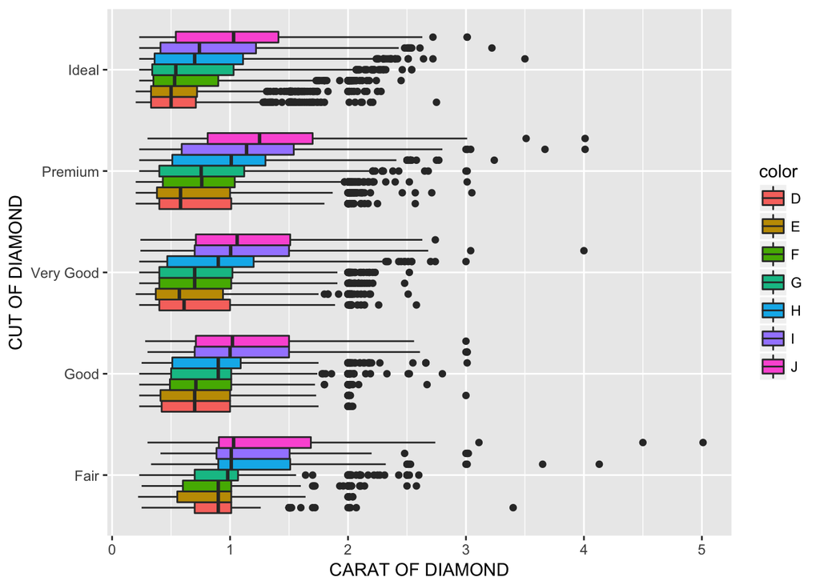

```r
ggplot(data = diamonds, mapping = aes(x = cut, y = carat, fill = color)) +
  geom_boxplot() +
  coord_flip() +

  ylab("CARAT OF DIAMOND") +
  xlab("CUT OF DIAMOND")
```

3.)

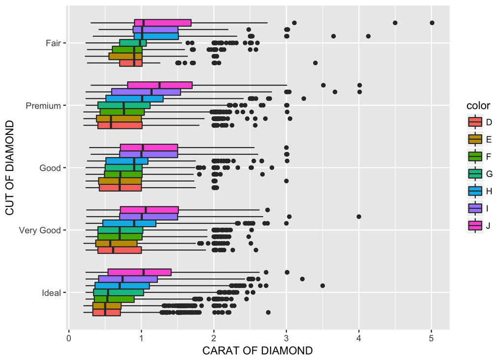

```r
ggplot(data = diamonds, mapping = aes(x = reorder(cut,carat,fun=median), y = carat, fill=color)) +
  geom_boxplot() +
  coord_flip() +

  ylab("CARAT OF DIAMOND") +
  xlab("CUT OF DIAMOND")
```

#### Data munging and wrangling

1.)

```r
spread(table2, key=type,value=count)
```

```
## # A tibble: 6 x 4
##   country      year  cases population
##   <chr>       <int>  <int>      <int>
## 1 Afghanistan  1999    745   19987071
## 2 Afghanistan  2000   2666   20595360
## 3 Brazil       1999  37737  172006362
## 4 Brazil       2000  80488  174504898
## 5 China        1999 212258 1272915272
## 6 China        2000 213766 1280428583
```

2.)

```r
diamonds %>%
  mutate(price_per_carat = price/carat)
```

```
## # A tibble: 53,940 x 11
##    carat cut       color clarity depth table price     x     y     z
##    <dbl> <ord>     <ord> <ord>   <dbl> <dbl> <int> <dbl> <dbl> <dbl>
##  1 0.230 Ideal     E     SI2      61.5  55.0   326  3.95  3.98  2.43
##  2 0.210 Premium   E     SI1      59.8  61.0   326  3.89  3.84  2.31
##  3 0.230 Good      E     VS1      56.9  65.0   327  4.05  4.07  2.31
##  4 0.290 Premium   I     VS2      62.4  58.0   334  4.20  4.23  2.63
##  5 0.310 Good      J     SI2      63.3  58.0   335  4.34  4.35  2.75
##  6 0.240 Very Good J     VVS2     62.8  57.0   336  3.94  3.96  2.48
##  7 0.240 Very Good I     VVS1     62.3  57.0   336  3.95  3.98  2.47
##  8 0.260 Very Good H     SI1      61.9  55.0   337  4.07  4.11  2.53
##  9 0.220 Fair      E     VS2      65.1  61.0   337  3.87  3.78  2.49
## 10 0.230 Very Good H     VS1      59.4  61.0   338  4.00  4.05  2.39
## # ... with 53,930 more rows, and 1 more variable: price_per_carat <dbl>
```

```r
diamonds %>%
  group_by(cut) %>%
  summarize(total = sum(price>10000 & carat<1.5),
            proportion = total/n())
```

```
## # A tibble: 5 x 3
##   cut       total proportion
##   <ord>     <int>      <dbl>
## 1 Fair          4    0.00248
## 2 Good         17    0.00347
## 3 Very Good   155    0.0128
## 4 Premium     173    0.0125
## 5 Ideal       485    0.0225
```

#### EDA

1.) The time period the data is from is 2000 - 2015.

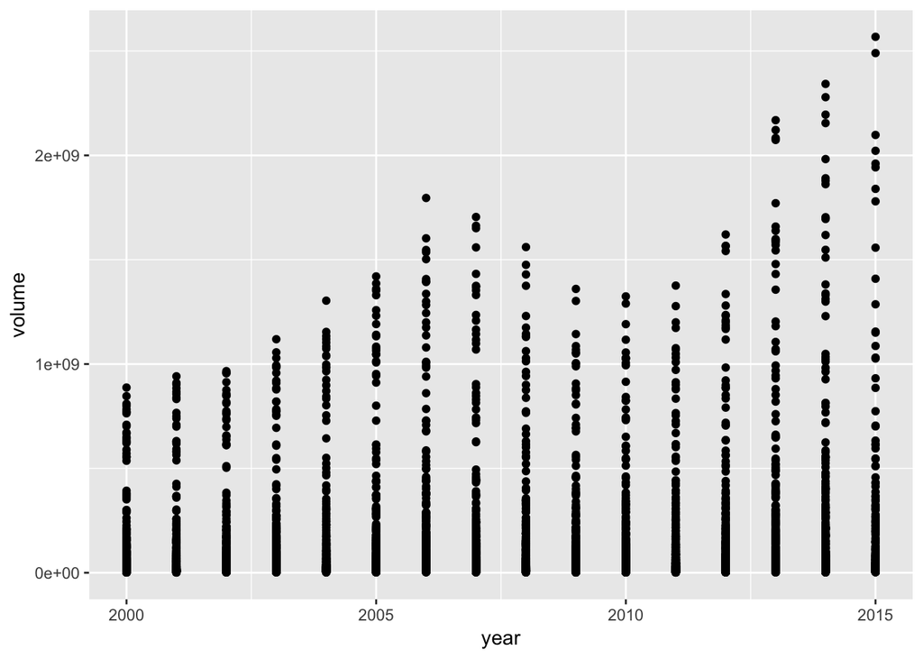

```r
ggplot(data = txhousing, mapping = aes(x= year, y = volume)) +
  geom_point()
```

2.) There are 46 cities represented in the data set.

```r
txhousing %>% summarize(cities = n_distinct(city))
```

```
## # A tibble: 1 x 1
##   cities
##    <int>
## 1     46
```

3.) Houston had the highest sales among cities.

```r
txhousing %>% group_by(city) %>%
  summarize(total_sales = sum(sales, na.rm = TRUE)) %>%
  arrange(desc(total_sales))
```

```
## # A tibble: 46 x 2
##    city              total_sales
##    <chr>                   <dbl>
##  1 Houston               1043999
##  2 Dallas                 816122
##  3 Austin                 373381
##  4 San Antonio            322097
##  5 Collin County          202892
##  6 Fort Bend              153088
##  7 Fort Worth             144791
##  8 NE Tarrant County      128007
##  9 Denton County          117405
## 10 Montgomery County      104589
## # ... with 36 more rows
```

The month with the highest sales was June.

```r
txhousing %>% group_by(month) %>%
  summarize(total_sales = sum(sales, na.rm = TRUE)) %>%
  arrange(desc(total_sales))
```

```
## # A tibble: 12 x 2
##    month total_sales
##    <int>       <dbl>
##  1     6      472732
##  2     7      454096
##  3     5      448968
##  4     8      417246
##  5     4      397332
##  6     3      386909
##  7     9      341654
##  8    10      332003
##  9    12      324843
## 10    11      297085
## 11     2      296410
## 12     1      245924
```

The year with the highest sales was 2006.

```r
txhousing %>% group_by(year) %>%
  summarize(total_sales = sum(sales, na.rm = TRUE)) %>%
  arrange(desc(total_sales))
```

```
## # A tibble: 16 x 2
##     year total_sales
##    <int>       <dbl>
##  1  2006      347733
##  2  2014      345720
##  3  2013      335094
##  4  2007      327701
##  5  2005      316046
##  6  2012      287052
##  7  2004      283999
##  8  2008      276664
##  9  2009      255254
## 10  2003      253909
## 11  2011      246356
## 12  2010      243014
## 13  2002      234600
## 14  2001      231453
## 15  2000      222483
## 16  2015      208124
```

4.) There is a linear relationship between the number of listings and number of sales, with sales increasing as the volume of listings grows. As the plot shows, the aggregate number of listings is higher than the aggregate sales volume.

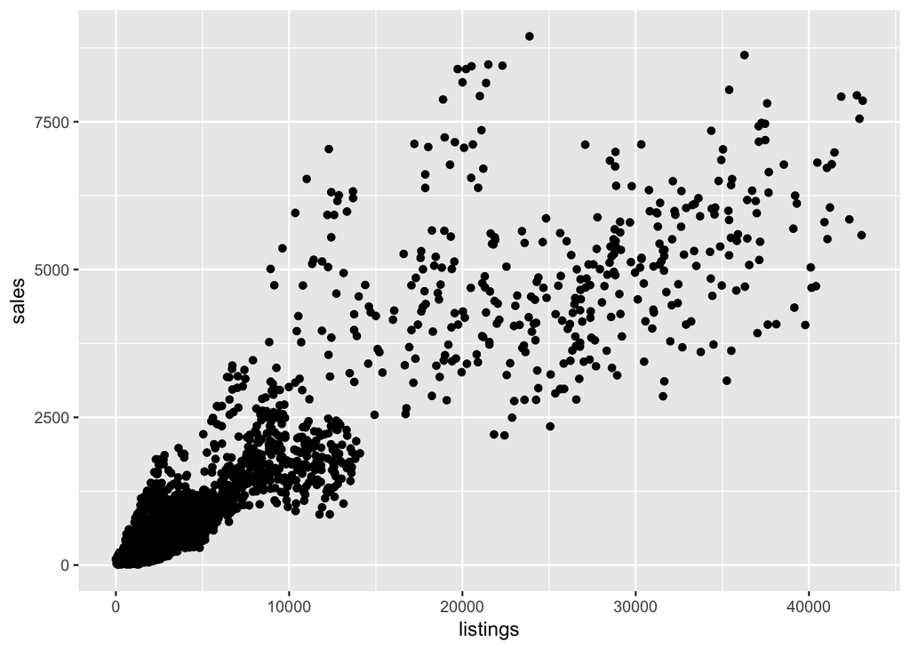

```r
filtered <- filter(txhousing, !is.na(sales), !is.na(listings))

ggplot(data=filtered, mapping = aes(x=listings, y=sales)) +
  geom_point() +
  geom_jitter()
```

5.)

```r
txhousing %>%
  group_by(city) %>%
  summarize(prop_missing = sum(is.na(sales)/n())) %>%
  arrange(desc(prop_missing))
```

```
## # A tibble: 46 x 2
##    city               prop_missing
##    <chr>                     <dbl>
##  1 South Padre Island       0.620
##  2 Kerrville                0.556
##  3 Midland                  0.401
##  4 Odessa                   0.385
##  5 San Marcos               0.246
##  6 Laredo                   0.193
##  7 Harlingen                0.134
##  8 Waco                     0.102
##  9 Texarkana                0.0909
## 10 Brazoria County          0.0749
## # ... with 36 more rows
```

6.) The distributions of the medial sales price vary significantly in that cities with similar median home prices have large variances in the standard deviation and median absolute deviation from the median. Cities that stand out with a high median absolute deviation from the median are Fort Bend and Austin. Filtering out cites/months with sales <500 cleans the data from the effects of time periods which don’t have enough data to draw reliable conclusions from, cities which are outliers in the dataset perhaps due to smaller populations, and external influences unrelated in nature to the real estate market (i.e. storms, earthquakes, and other natural disasters).

```r
txhousing %>%
  group_by(city) %>%
  filter(sales>500) %>%
  summarize(med = median(median), sd = sd(median), test2 = mad(median)) %>%
  arrange(desc(test2))
```

```
## # A tibble: 14 x 4
##    city                 med    sd test2
##    <chr>              <dbl> <dbl> <dbl>
##  1 Fort Bend         177500 38176 35212
##  2 Austin            179400 30987 32765
##  3 Montgomery County 178750 29979 27947
##  4 Collin County     196000 31347 27725
##  5 San Antonio       143300 27052 25946
##  6 Bay Area          156250 19384 20163
##  7 Houston           148400 24214 19126
##  8 NE Tarrant County 160800 21764 17495
##  9 El Paso           131200 20692 15419
## 10 Dallas            154500 22727 13492
## 11 Fort Worth        114600 16786 13047
## 12 Denton County     163200 20738 12157
## 13 Arlington         129300 18741  8599
## 14 Corpus Christi    129300  3546  2817
```